# Hechos estilizados

Miguel G.

13/2/2023

# Introducción a los hechos estilizados del rendimiento

Recordemos que un hecho estilizado es una peculiaridad empirica sobre el rendimiento de los activos.

Vamos a ver el comportamiendo de un activo para verificar empiricamente los hechos estilizados.

Vamos a utilizar los datos del archivo “ejemplo_rendimiento.xlsx”, el cual contiene el precio y rendimiento diario de las acciones de McDonald’s, en el periodo de 2013 a 2023. La fue de estos datos es Factset.

Iniciamos en análisis de la manera estándar, cargamos datos y manipulación de datos.

```r
rm(list=ls())
setwd("C:/Users/Miike/Desktop")

library(PerformanceAnalytics)
library(quantmod)
library(tidyverse)
library(readxl)
library(lubridate)

activo <- read_excel("ejemplo_rendimiento.xlsx")

activo <- activo %>%
  mutate(date=as.POSIXct( ymd(dmy(date)) ))

rendimiento <- xts(x=activo$rend, order.by = activo$date)

precio <- xts(x=activo$precio, order.by = activo$date)
```

# Hecho estilizado 1

Hecho estilizado 1: Los precios de los activos y el valor de los portafolios siguen una caminata aleatoria.

La siguiente gráfica muestra el comportamiento de los precios:

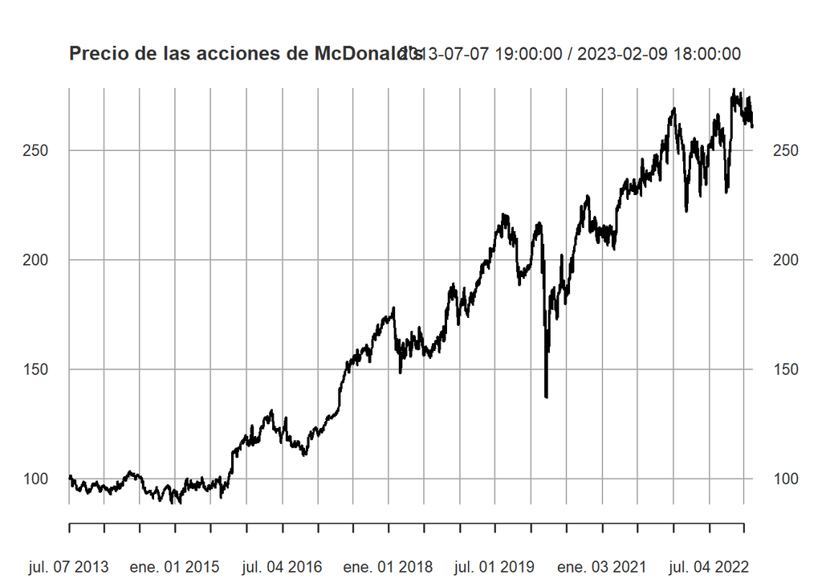

```r
plot(precio, main="Precio de las acciones de McDonald's")
```

El comportamiento errático de una variable aleatoria se describe por medio de un proceso estocástico que se llama *camina aleatoria*. Esto significa que el precio de un activo sigue el siguiente movimiento:

$$S_t=S_{t-1}+\epsilon$$

Donde $E[\epsilon_t]=0$ y $E[\epsilon_t, \epsilon_{t-1}]=Cov[\epsilon_t, \epsilon_{t-1}]=0$ Esto tiene las siguientes implicaciones: * No hay correlación entre los retornos de un periodo con los anteriores. El rendimiento no tiene memoria. * Formación eficiente de los precios, el precio actual de un activo refleja toda la información existente para darle valor, el ajuste de precios ante cambios se lleva a cabo rápidamente.

Anteriormente simulamos procesos estocáticos. Vamos a generar un proceso de Wiener Generalizado para comparar el comportamiento de mi activo contra una simulación:

```r
set.seed(1234)

obs <- 2418
dt <- 1/obs
epsilon <- rnorm(obs, mean = 0, sd=1)

dW <- epsilon*sqrt(dt)

datos <- tibble(
  t=seq(from=dt, to=1, by=dt),
  dW
)

a <- 175
b <- 99

dx <- a*dt+b*dW

X <- 100

X[1] <- X

for(t in 2:obs){
  X[t] <- X[t-1]+dx[t]
}

datos <- mutate(datos, X=X, dX=dx)

cruce <- cbind(datos, activo)

cruce <- cruce %>%
  select(precio, X, date) %>%
  gather("Variable", "Valor", -date)
```

Vamos a graficar ambas variables para observar el comportamiento:

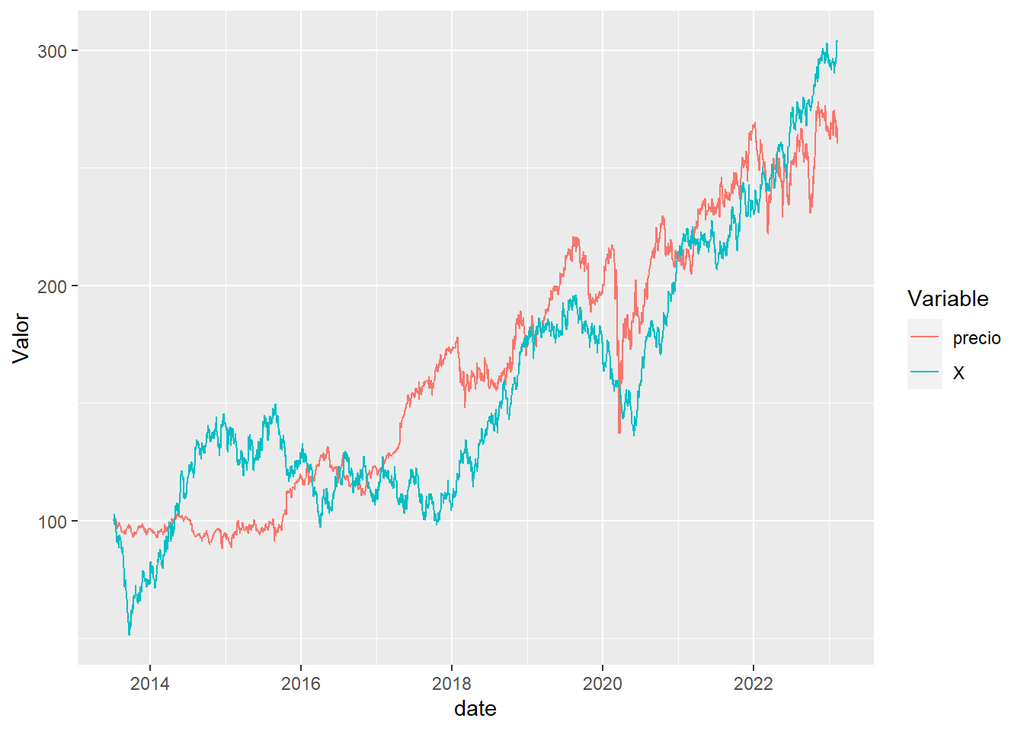

```r
ggplot(cruce, aes(x=date, y=Valor, group=Variable))+
  geom_line(aes(color=Variable))
```

# Hecho estilizado 2

La distribución de los rendimientos es aproximadamente acampanada.

Una característica del rendimiento del precio de los activos, es que si graficamos un histograma, observamos un comportamiento de campana, aunque con ciertas deformaciones. Un comportamiento de campana hace referencia a lo que en estadística se conoce como distribución normal.

La siguiente gráfica muestra un histograma del rendimiento de nuestra acción:

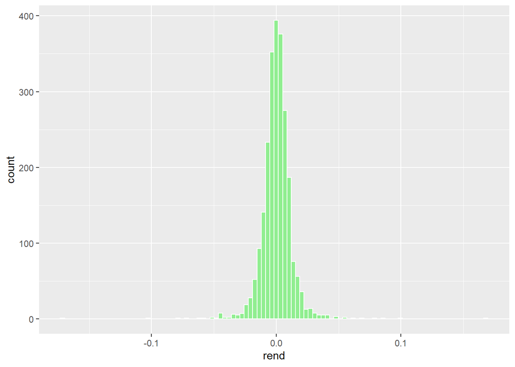

```r
activo %>%
  ggplot(aes(x=rend))+
  geom_histogram(bins=100, fill="lightgreen", color="white")
```

Como la distribución del precio:

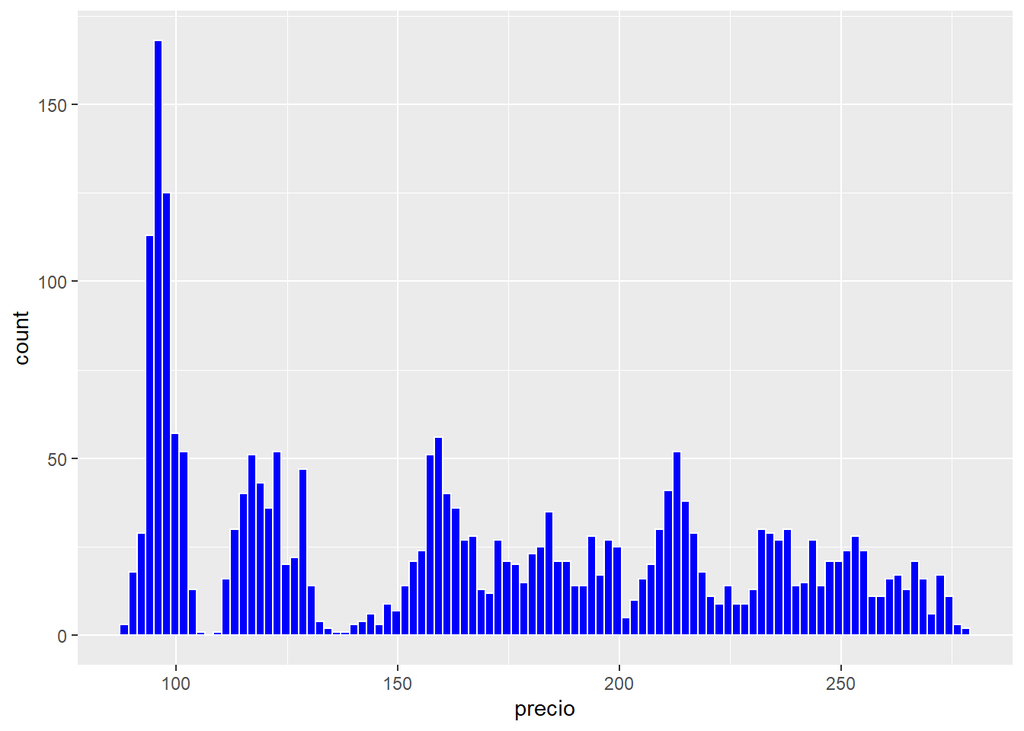

```r
activo %>%
  ggplot(aes(x=precio))+
  geom_histogram(bins=100, fill="blue", color="white")
```

# Hecho estilizado 3

Los rendimientos de los activos presentan volatilidad no constante y agrupada.

Analizamos las bandas de Bollinger:

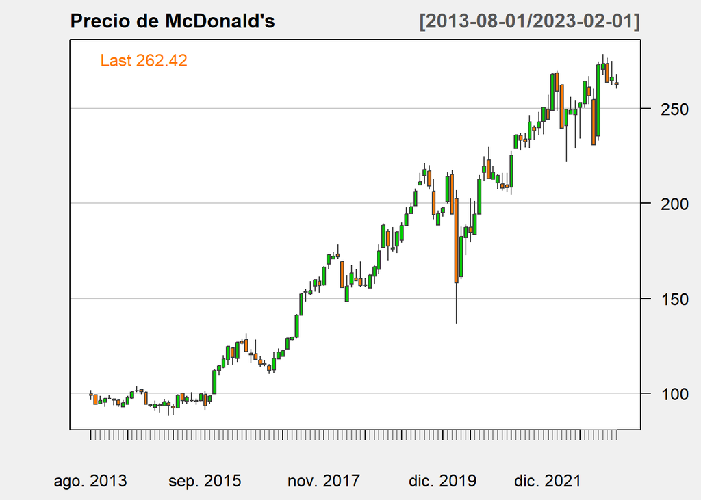

```r
chartSeries(to.monthly(precio), name="Precio de McDonald's", theme="white")
```

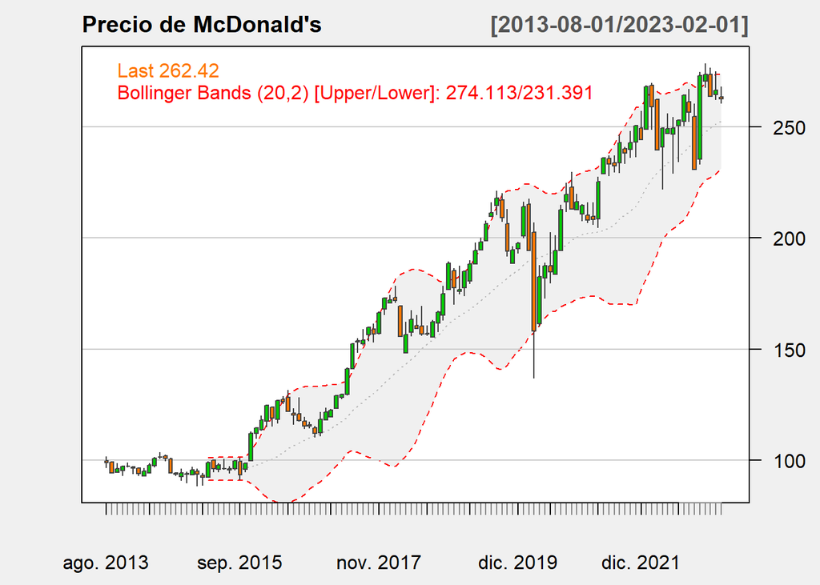

```r
addBBands()
```

Las bandas que se muestran alrededor de la trayectoria del precio son las Bandas de Bollinger y miden la volatilidad del mercado. El 95% del precio deberá situarse dentro de estas bandas, de forma resumida decimos que:

- En un mercado más volátil, las bandas de Bollinger se expanden
- En un mercado menos volátil, las bandas se contraen

# Hecho estilizado 4

La distribución de los rendimientos presenta leptocurtosis.

La distribución de los rendimientos es más *picuda* y de colas pesadas. Esto implica que hay mayores posibilidades de obtener valores más cercanos a la media, que en la distribución normal.

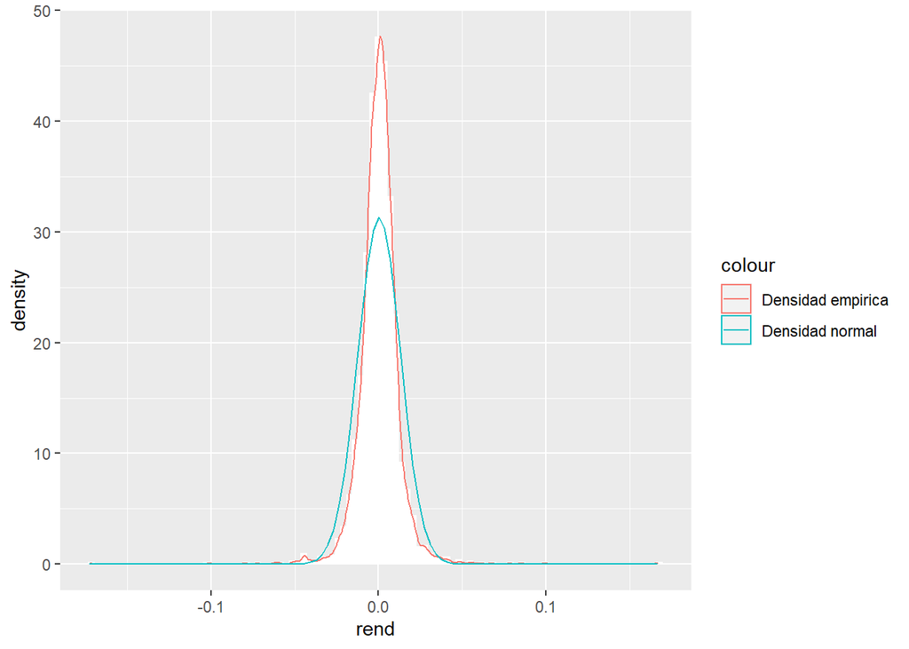

```r
activo %>%
  ggplot(aes(x=rend))+
  geom_histogram(aes(y=..density..) ,bins=100, fill="white", color="white")+
  geom_density(aes(x=rend, col="Densidad empirica"))+
  stat_function(fun=dnorm, args =
                  list(
                    mean=mean(activo$rend),
                    sd=sd(activo$rend)), aes(col="Densidad normal"))
```